# Attribute operations in R

## Prerequisites

- In this section we require the following packages:

```r
library(sf)
library(raster)
library(tidyverse)
library(dplyr)
```

- It also relies on **spData**, which loads datasets used in the code examples of this chapter:

```r
library(spData)
```

## Introduction

Please note that most text and code in this notebook has been taken from [Geocomputation with R](https://geocompr.robinlovelace.net/) book, authored by Robin Lovelace, Jakub Nowosad, and Jannes Muenchow. In addition to evaluating each cunk of code, in this notebook the world countries dataset used as example has been changed as well as some lines of the original code.

Attribute data is non-spatial information associated with geographic (geometry) data.

The focus of this session is manipulating geographic objects based on attributes such as the name of a bus stop and elevation.

For vector data this means operations such as **subsetting**, **aggregation**, and **attribute joins**.

For raster attribute this means operations such as **extracting cell values** (raster subsetting) as well as __summarizing_ entire raster layers or stacks.

## Vector attribute manipulation

Geographic vector data in R are well-support by `sf`, a class which extends the `data.frame`.

Thus `sf` objects have one column per attribute variable and one row per observation, or *feature*. `sf` objects also have a special column to contain geometry data, usually named `geometry`.

The `geometry` column is special because it is a *list-colum*, which can contain multiple geographic entities (points, lines, polygons) per row.

**sf** also provides methods that allow `sf` objects to behave like regular data frames:

```r
methods(class = "sf") # methods for sf objects
```

Many of these functions, including `rbind()` and `$<-` were developed for data frames.

Before starting with **sf**, let’s download a shapefile representing world countries borders -processed by [Bjørn Sandvik](http://thematicmapping.org)-, unzip it and read it:

```r
#download.file("http://thematicmapping.org/downloads/TM_WORLD_BORDERS-0.3.zip",
#destfile = "./datos/tm_world.zip" , mode='wb')

#unzip("./datos/tm_world.zip", exdir = "./datos")

### reading a shapefile
library(sf)
world <- st_read("./datos/TM_WORLD_BORDERS-0.3.shp")
class(world)
```

```
## [1] "sf"         "data.frame"
```

A key feature of `sf` objects is that they store spatial and non-spatial data in the same way, as columns in a `data.frame`.

The geometry column of `sf` objects is typically called `geometry` but any name can be used. The following command, for example, creates a geometry column named g:

`st_sf(data.frame(n = world$name_long), g = world$geom)`

This enables geometries imported from spatial databases to have a variety of names such as `wkb_geometry` and `the_geom`.

`sf` objects also support `tibble` and `tbl` classes used in the tidyverse, allowing ‘tidy’ data analysis workflows for spatial data. Thus **sf** enables the full power of R’s data analysis capabilities to be unleashed on geographic data. Before using these capabilities it’s worth re-capping how to discover the basic properties of vector data objects. Let’s start by using base R functions to get a measure of the `world` dataset:

```r
dim(world) # it is a 2 dimensional object, with rows and columns
```

```
## [1] 246  12
```

```r
nrow(world) # how many rows?
```

```
## [1] 246
```

```r
ncol(world) # how many columns?
```

```
## [1] 12
```

Our dataset contains several non-geographic columns (and one geometry list-column) with more then 200 rows representing the world’s countries. Extracting the attribute data of an `sf` object is the same as removing its geometry:

```r
world_df = st_set_geometry(world, NULL)
class(world_df)
```

```
## [1] "data.frame"
```

This can be useful if the geometry column causes problems, e.g. by occupying large amounts of RAM, or to focus the attention on the attribute data. For most cases, however, there is no harm in keeping the geometry column.

For many applications, the tidyverse package **dplyr** offers the most effective and intuitive approach for working with data frames.

### Vector attribute subsetting

Base R subsetting functions include `[`, `subset()` and `$`. **dplyr** subsetting functions include `select()`, `filter()`, and `pull()`. Both sets of functions preserve the spatial components of attribute data in `sf` objects.

The `[` operator can subset both rows and columns. The examples below demonstrate subsetting with base R.

```r
world[10:15, ] # subset rows by position
```

|  | FIPS | ISO2 | ISO3 | UN | NAME | AREA | POP2005 | REGION | SUBREGION | LON | LAT | geometry |
| --- | --- | --- | --- | --- | --- | --- | --- | --- | --- | --- | --- | --- |
| 10 | BA | BH | BHR | 48 | Bahrain | 71 | 724788 | 142 | 145 | 50.562 | 26.019 |  |
| 11 | BB | BB | BRB | 52 | Barbados | 43 | 291933 | 19 | 29 | -59.559 | 13.153 |  |
| 12 | BD | BM | BMU | 60 | Bermuda | 5 | 64174 | 19 | 21 | -64.709 | 32.336 |  |
| 13 | BF | BS | BHS | 44 | Bahamas | 1001 | 323295 | 19 | 29 | -78.014 | 24.628 |  |
| 14 | BG | BD | BGD | 50 | Bangladesh | 13017 | 15328112 | 142 | 34 | 89.941 | 24.218 |  |
| 15 | BH | BZ | BLZ | 84 | Belize | 2281 | 275546 | 19 | 13 | -88.602 | 17.219 |  |

```r
world[, 1:3] # subset columns by position
```

| FIPS | ISO2 | ISO3 | geometry |
| --- | --- | --- | --- |
| AC | AG | ATG |  |
| AG | DZ | DZA |  |
| AJ | AZ | AZE |  |
| AL | AL | ALB |  |
| AM | AM | ARM |  |
| AO | AO | AGO |  |
| AQ | AS | ASM |  |
| AR | AR | ARG |  |
| AS | AU | AUS |  |
| BA | BH | BHR |  |

[output cut: 236 more lines]

```r
world[, c("NAME", "POP2005")] # subset columns by name
```

| NAME | POP2005 | geometry |
| --- | --- | --- |
| Antigua and Barbuda | 83039 |  |
| Algeria | 32854159 |  |
| Azerbaijan | 8352021 |  |
| Albania | 3153731 |  |
| Armenia | 3017661 |  |
| Angola | 16095214 |  |
| American Samoa | 64051 |  |
| Argentina | 38747148 |  |
| Australia | 20310208 |  |
| Bahrain | 724788 |  |

[output cut: 236 more lines]

```r
sel_area = world$AREA > 500000
summary(sel_area) # a logical vector
```

```
##    Mode   FALSE    TRUE
## logical     240       6
```

```r
big_countries = world[sel_area, ]
print(big_countries)
```

```
## Simple feature collection with 6 features and 11 fields
## geometry type:  MULTIPOLYGON
## dimension:      XY
## bbox:           xmin: -180 ymin: -54.75389 xmax: 180 ymax: 83.11388
## epsg (SRID):    4326
## proj4string:    +proj=longlat +datum=WGS84 +no_defs
##     FIPS ISO2 ISO3  UN          NAME    AREA    POP2005 REGION SUBREGION
## 9     AS   AU  AUS  36     Australia  768230   20310208      9        53
## 21    BR   BR  BRA  76        Brazil  845942  186830759     19         5
## 24    CA   CA  CAN 124        Canada  909351   32270507     19        21
## 30    CH   CN  CHN 156         China  932743 1312978855    142        30
## 175   RS   RU  RUS 643        Russia 1638094  143953092    150       151
## 209   US   US  USA 840 United States  915896  299846449     19        21
##          LON     LAT                       geometry
## 9    136.189 -24.973 MULTIPOLYGON (((158.8822 -5...
## 21   -53.089 -10.772 MULTIPOLYGON (((-48.55056 -...
## 24  -109.433  59.081 MULTIPOLYGON (((-65.61362 4...
## 30   106.514  33.420 MULTIPOLYGON (((110.5241 19...
## 175   96.689  61.988 MULTIPOLYGON (((131.8733 42...
## 209  -98.606  39.622 MULTIPOLYGON (((-75.17029 1...
```

The base R function `subset()` provides yet another way to achieve the same result:

```r
nbig_countries = subset(world, AREA > 500000)
nbig_countries
```

|  | FIPS | ISO2 | ISO3 | UN | NAME | AREA | POP2005 | REGION | SUBREGION | LON | LAT | geometry |
| --- | --- | --- | --- | --- | --- | --- | --- | --- | --- | --- | --- | --- |
| 9 | AS | AU | AUS | 36 | Australia | 768230 | 20310208 | 9 | 53 | 136.189 | -24.973 |  |
| 21 | BR | BR | BRA | 76 | Brazil | 845942 | 186830759 | 19 | 5 | -53.089 | -10.772 |  |
| 24 | CA | CA | CAN | 124 | Canada | 909351 | 32270507 | 19 | 21 | -109.433 | 59.081 |  |
| 30 | CH | CN | CHN | 156 | China | 932743 | 1312978855 | 142 | 30 | 106.514 | 33.420 |  |
| 175 | RS | RU | RUS | 643 | Russia | 1638094 | 143953092 | 150 | 151 | 96.689 | 61.988 |  |
| 209 | US | US | USA | 840 | United States | 915896 | 299846449 | 19 | 21 | -98.606 | 39.622 |  |

```r
brazil = subset(world, NAME == "Brazil")
brazil
```

|  | FIPS | ISO2 | ISO3 | UN | NAME | AREA | POP2005 | REGION | SUBREGION | LON | LAT | geometry |
| --- | --- | --- | --- | --- | --- | --- | --- | --- | --- | --- | --- | --- |
| 21 | BR | BR | BRA | 76 | Brazil | 845942 | 186830759 | 19 | 5 | -53.089 | -10.772 |  |

Base R functions are mature and widely used.

However, the more recent **dplyr** approach has several advantages. It enables intuitive workflows. It is fast, due to its C++ backend. This is especially useful when working with big data as well as **dplyr**’s database integration. The main **dplyr** subsetting functions are `select()`, `slice()`, `filter()` and `pull()`.

`select()` selects columns by name or position. For example, you could select only two columns, `NAME` and `POP2005`, with the following command (note the sticky `geom` column remains):

```r
names(world)
```

```
##  [1] "FIPS"      "ISO2"      "ISO3"      "UN"        "NAME"
##  [6] "AREA"      "POP2005"   "REGION"    "SUBREGION" "LON"
## [11] "LAT"       "geometry"
```

```r
world1 = dplyr::select(world, NAME, POP2005)
names(world1)
```

```
## [1] "NAME"     "POP2005"  "geometry"
```

`select()` also allows subsetting of a range of columns with the help of the `:` operator:

```r
# all columns between name_long and pop (inclusive)
world2 = dplyr::select(world, NAME:SUBREGION)
print(world2, n=5)
```

```
## Simple feature collection with 246 features and 5 fields
## geometry type:  MULTIPOLYGON
## dimension:      XY
## bbox:           xmin: -180 ymin: -90 xmax: 180 ymax: 83.6236
## epsg (SRID):    4326
## proj4string:    +proj=longlat +datum=WGS84 +no_defs
## First 5 features:
##                  NAME   AREA  POP2005 REGION SUBREGION
## 1 Antigua and Barbuda     44    83039     19        29
## 2             Algeria 238174 32854159      2        15
## 3          Azerbaijan   8260  8352021    142       145
## 4             Albania   2740  3153731    150        39
## 5             Armenia   2820  3017661    142       145
##                         geometry
## 1 MULTIPOLYGON (((-61.68667 1...
## 2 MULTIPOLYGON (((2.96361 36....
## 3 MULTIPOLYGON (((45.08332 39...
## 4 MULTIPOLYGON (((19.43621 41...
## 5 MULTIPOLYGON (((45.57305 40...
```

Omit specific columns with the `-` operator:

```r
# all columns except subregion and area (inclusive)
world3 = dplyr::select(world, -SUBREGION, -AREA)
names(world3)
```

```
##  [1] "FIPS"     "ISO2"     "ISO3"     "UN"       "NAME"     "POP2005"
##  [7] "REGION"   "LON"      "LAT"      "geometry"
```

Conveniently, `select()` lets you subset and rename columns at the same time, for example:

```r
world4 = dplyr::select(world, NAME, POPULATION = POP2005)
names(world4)
```

```
## [1] "NAME"       "POPULATION" "geometry"
```

`select()` also works with ‘helper functions’ for advanced subsetting operations, including `contains()`, `starts_with()` and `num_range()` (see the help page with `?select` for details).

All **dplyr** functions including `select()` always return a data frame-like object.

Due to the sticky geometry column, selecting a single attribute from an sf-object with the help of `[()` returns also a data frame. Contrastingly, `pull()` and `$` will give back a vector.

```r
# data frame object
world[, "POP2005"]
```

| POP2005 | geometry |
| --- | --- |
| 83039 |  |
| 32854159 |  |
| 8352021 |  |
| 3153731 |  |
| 3017661 |  |
| 16095214 |  |
| 64051 |  |
| 38747148 |  |
| 20310208 |  |
| 724788 |  |

[output cut: 236 more lines]

`slice()` is the row-equivalent of `select()`. The following code chunk, for example, selects the 13<sup>rd</sup> to 18<sup>th</sup> rows:

```r
slice(world, 13:18)
```

```r
# Countries with with land area larger than 2 million km^2
world6 = filter(world, AREA > 200000)
world6
```

| FIPS | ISO2 | ISO3 | UN | NAME | AREA | POP2005 | REGION | SUBREGION | LON | LAT | geometry |
| --- | --- | --- | --- | --- | --- | --- | --- | --- | --- | --- | --- |
| AG | DZ | DZA | 12 | Algeria | 238174 | 32854159 | 2 | 15 | 2.632 | 28.163 |  |
| AR | AR | ARG | 32 | Argentina | 273669 | 38747148 | 19 | 5 | -65.167 | -35.377 |  |
| AS | AU | AUS | 36 | Australia | 768230 | 20310208 | 9 | 53 | 136.189 | -24.973 |  |
| BR | BR | BRA | 76 | Brazil | 845942 | 186830759 | 19 | 5 | -53.089 | -10.772 |  |
| CA | CA | CAN | 124 | Canada | 909351 | 32270507 | 19 | 21 | -109.433 | 59.081 |  |
| CG | CD | COD | 180 | Democratic Republic of the Congo | 226705 | 58740547 | 2 | 17 | 23.654 | -2.876 |  |
| CH | CN | CHN | 156 | China | 932743 | 1312978855 | 142 | 30 | 106.514 | 33.420 |  |
| IN | IN | IND | 356 | India | 297319 | 1134403141 | 142 | 34 | 78.500 | 21.000 |  |
| KZ | KZ | KAZ | 398 | Kazakhstan | 269970 | 15210609 | 142 | 143 | 67.301 | 48.160 |  |
| RS | RU | RUS | 643 | Russia | 1638094 | 143953092 | 150 | 151 | 96.689 | 61.988 |  |

[output cut: 3 more lines]

The standard set of comparison operators can be used in the `filter()` function, as illustrated in Table @ref(tab:operators):

Table of comparison operators that result in boolean (TRUE/FALSE) outputs.

| Symbol | Name |
| --- | --- |
| `==` | Equal to |
| `!=` | Not equal to |
| `>, <` | Greater/Less than |
| `>=, <=` | Greater/Less than or equal |
| `&, \|, !` | Logical operators: And, Or, Not |

```r
world7 = world %>%
  filter(REGION == 2) %>%
  dplyr::select(NAME, REGION) %>%
  slice(1:5)

world7
```

| NAME | REGION | geometry |
| --- | --- | --- |
| Algeria | 2 |  |
| Angola | 2 |  |
| Benin | 2 |  |
| Congo | 2 |  |
| Democratic Republic of the Congo | 2 |  |

The above chunk shows how the pipe operator allows commands to be written in a clear order: the above run from top to bottom (line-by-line) and left to right. The alternative to `%>%` is nested function calls, which is harder to read:

```r
world8 = slice(
  dplyr::select(
    filter(world, REGION == 2),
    NAME, REGION),
  1:5)

world8
```

| NAME | REGION | geometry |
| --- | --- | --- |
| Algeria | 2 |  |
| Angola | 2 |  |
| Benin | 2 |  |
| Congo | 2 |  |
| Democratic Republic of the Congo | 2 |  |

### Vector attribute aggregation

```r
world_agg1 = aggregate(POP2005 ~ REGION, FUN = sum, data = world, na.rm = TRUE)
class(world_agg1)
```

```
## [1] "data.frame"
```

```r
world_agg1
```

| REGION | POP2005 |
| --- | --- |
| 0 | 0 |
| 2 | 868747961 |
| 9 | 33207568 |
| 19 | 843476450 |
| 142 | 3766985417 |
| 150 | 659304178 |

The result is a non-spatial data frame with six rows, one per region, and two columns reporting the name and population of each region. In this [link](https://unstats.un.org/unsd/methodology/m49/) you can find codes for different geographic regions

`aggregate()` is a generic function which means that it behaves differently depending on its inputs. **sf** provides a function that can be called directly with `sf:::aggregate()` that is activated when a `by` argument is provided, rather than using the `~` to refer to the grouping variable:

```r
library(lwgeom)
cworld <- world %>% st_set_precision(10000) %>% lwgeom::st_make_valid()
world_agg2 = aggregate(cworld["POP2005"], by = list(cworld$REGION),
                       FUN = sum, na.rm = TRUE)
print(world_agg2)
```

```
## Simple feature collection with 6 features and 2 fields
## Attribute-geometry relationship: 0 constant, 1 aggregate, 1 identity
## geometry type:  MULTIPOLYGON
## dimension:      XY
## bbox:           xmin: -180 ymin: -90 xmax: 180 ymax: 83.6236
## epsg (SRID):    4326
## proj4string:    +proj=longlat +datum=WGS84 +no_defs
##   Group.1    POP2005                       geometry
## 1       0          0 MULTIPOLYGON (((-149.832 -7...
## 2       2  868747961 MULTIPOLYGON (((37.8508 -46...
## 3       9   33207568 MULTIPOLYGON (((158.8822 -5...
## 4      19  843476450 MULTIPOLYGON (((-67.4931 -5...
## 5     142 3766985417 MULTIPOLYGON (((123.2147 -1...
## 6     150  659304178 MULTIPOLYGON (((-17.9128 27...
```

As illustrated above, an object of class `sf` is returned this time. `world_agg2` which is a spatial object containing 6 polygons representing the columns of the world.

`summarize()` is the **dplyr** equivalent of `aggregate()`. It usually follows `group_by()`, which specifies the grouping variable, as illustrated below:

```r
world_agg3 = cworld %>%
  group_by(REGION) %>%
  summarize(POP = sum(POP2005, na.rm = TRUE))

print(world_agg3)
```

```
## Simple feature collection with 6 features and 2 fields
## geometry type:  MULTIPOLYGON
## dimension:      XY
## bbox:           xmin: -180 ymin: -90 xmax: 180 ymax: 83.6236
## epsg (SRID):    4326
## proj4string:    +proj=longlat +datum=WGS84 +no_defs
## # A tibble: 6 x 3
##   REGION       POP                                                geometry
##    <int>     <dbl>                                      <MULTIPOLYGON [°]>
## 1      0    0.     (((-149.832 -76.6645, -149.7956 -76.6747, -149.7711 -7…
## 2      2    8.69e8 (((37.8508 -46.9569, 37.8464 -46.9608, 37.8355 -46.967…
## 3      9    3.32e7 (((158.8822 -54.7114, 158.8797 -54.7539, 158.8369 -54.…
## 4     19    8.43e8 (((-67.4931 -55.8292, -67.4942 -55.8342, -67.5217 -55.…
## 5    142    3.77e9 (((123.2147 -10.8122, 123.1983 -10.8231, 123.1886 -10.…
## 6    150    6.59e8 (((-17.9128 27.7717, -17.9628 27.6847, -17.965 27.68, …
```

```r
cworld %>%
  summarize(pop = sum(POP2005, na.rm = TRUE), n = n())
```

|  | pop | n | geometry |
| --- | --- | --- | --- |
| 1 | 6171721574 | 246 |  |

In the previous code chunk `pop` and `n` are column names in the result. `sum()` and `n()` were the aggregating functions. The result is an `sf` object with a single row representing the world (this works thanks to the geometric operation ‘union’, as explained in section @ref(geometry-unions)).

Let’s combine what we’ve learned so far about **dplyr** by chaining together functions to find the world’s 3 most populous continents (with `dplyr::n()` ) and the number of countries they contain (the result of this command is presented in Table @ref(tab:continents)):

```r
cworld %>%
  dplyr::select(POP2005, REGION) %>%
  group_by(REGION) %>%
  summarize(pop = sum(POP2005, na.rm = TRUE), n_countries = n()) %>%
  top_n(n = 3, wt = pop) %>%
  st_set_geometry(value = NULL)
```

|  | REGION | pop | n_countries |
| --- | --- | --- | --- |
| 1 | 2 | 868747961 | 57 |
| 2 | 19 | 843476450 | 53 |
| 3 | 142 | 3766985417 | 50 |

The top 3 most populous regions, and the number of countries in each.

| REGION | POP2005 | n_countries |
| --- | --- | --- |
| 2 | 868747961 | 57 |
| 19 | 843476450 | 53 |
| 142 | 3766985417 | 50 |

### Vector attribute joining

Combining data from different sources is a common task in data preparation. Joins do this by combining tables based on a shared ‘key’ variable. **dplyr** has multiple join functions including `left_join()` and `inner_join()` — see `vignette("two-table")` for a full list. These function names follow conventions used in the database language [SQL](http://r4ds.had.co.nz/relational-data.html) [@grolemund_r_2016, Chapter 13]; using them to join non spatial datasets to `sf` objects is the focus of this section. **dplyr** join functions work the same on data frames and `sf` objects, the only important difference being the `geometry` list column. The result of data joins can be either an `sf` or `data.frame` object. The most common type of attribute join on spatial data takes an `sf` object as the first argument and adds columns to it from a `data.frame` specified as the second argument.

To demonstrate joins, we will combine data on coffee production with the `world` dataset. The coffee data is in a data frame called `coffee_data` from the **spData** package (see `?coffee_data` for details). It has 3 columns: `name_long` names major coffee-producing nations and `coffee_production_2016` and `coffee_production_2017` contain estimated values for coffee production in units of 60 kg bags in each year. A ‘left join’, which preserves the first dataset, merges `world` with `coffee_data`:

```r
coffee_data$NAME = coffee_data$name_long
world_coffee = left_join(cworld, coffee_data)
class(world_coffee)
```

```
## [1] "sf"         "data.frame"
```

```r
names(world_coffee)
```

```
##  [1] "FIPS"                   "ISO2"
##  [3] "ISO3"                   "UN"
##  [5] "NAME"                   "AREA"
##  [7] "POP2005"                "REGION"
##  [9] "SUBREGION"              "LON"
## [11] "LAT"                    "name_long"
## [13] "coffee_production_2016" "coffee_production_2017"
## [15] "geometry"
```

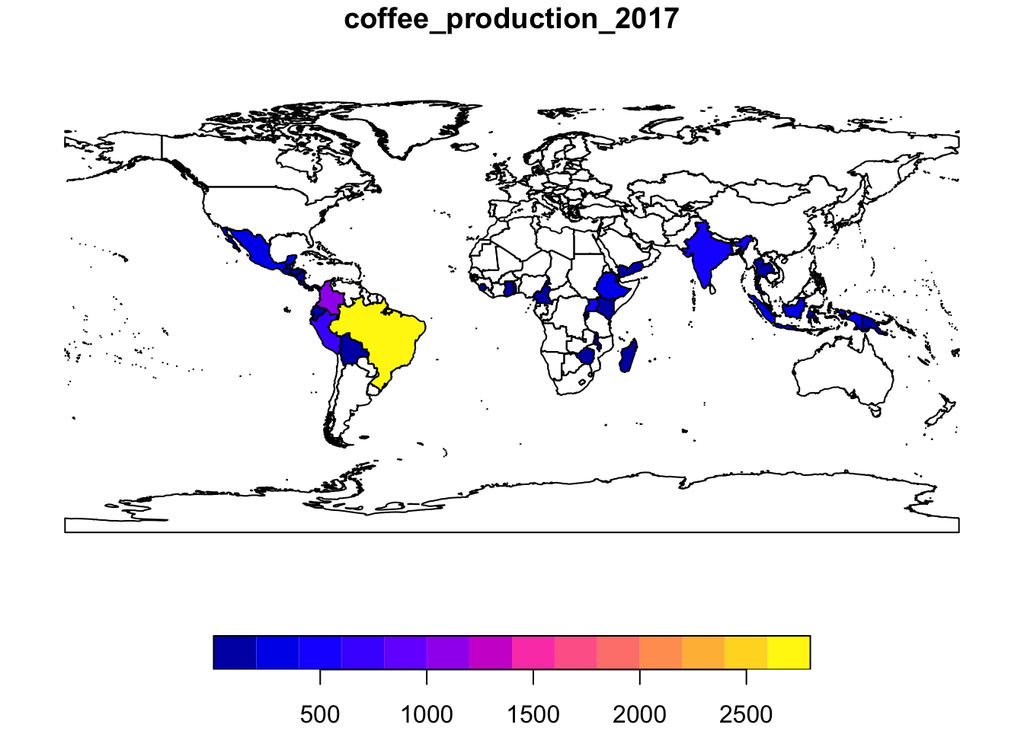

```r
plot(world_coffee["coffee_production_2017"])
```

1. Rename the key variable in one of the objects so they match.
2. Use the `by` argument to specify the joining variables.

The latter approach is demonstrated below on a renamed version of `coffee_data`:

```r
coffee_renamed = rename(coffee_data, name2 = name_long)
world_coffee2 = left_join(cworld, coffee_renamed, by = c(NAME = "name2"))
```

```r
world_coffee_inner = inner_join(cworld, coffee_data)
nrow(world_coffee_inner)
```

```
## [1] 42
```

Note that the result of `inner_join()` has only 42 rows compared with 47 in `coffee_data`. What happened to the remaining rows? We can identify the rows that did not match using the `setdiff()` function as follows:

```r
setdiff(coffee_data$NAME, cworld$NAME)
```

```
## [1] "Congo, Dem. Rep. of" "Côte d'Ivoire"       "Tanzania"
## [4] "Vietnam"             "Others"
```

```r
str_subset(world$name_long, "Dem*.+Congo")
```

```
## character(0)
```

```r
coffee_data$name_long[grepl("Congo,", coffee_data$NAME)] =
  str_subset(cworld$NAME, "Dem*.+Congo")
world_coffee_match = inner_join(cworld, coffee_data)
nrow(world_coffee_match)
```

```
## [1] 42
```

It is also possible to join in the other direction: starting with a non-spatial dataset and adding variables from a simple features object. This is demonstrated below, which starts with the `coffee_data` object and adds variables from the original `world` dataset. In contrast with the previous joins, the result is *not* another simple feature object, but a data frame in the form of a **tidyverse** tibble: the output of a join tends to match its first argument:

```r
coffee_world = left_join(coffee_data, cworld)
class(coffee_world)
```

```
## [1] "tbl_df"     "tbl"        "data.frame"
```

In most cases the geometry column is only useful in an `sf` object. The geometry column can only be used for creating maps and spatial operations if R ‘knows’ it is a spatial object, defined by a spatial package such as **sf**. Fortunately non-spatial data frames with a geometry list column (like `coffee_world`) can be coerced into an `sf` object as follows: `st_as_sf(coffee_world)`.

This section covers the majority joining use cases. For more information we recommend @grolemund_r_2016, the [join vignette](https://geocompr.github.io/geocompkg/articles/join.html) in the **geocompkg** package that accompanies this book, and documentation of the **data.table** package.[^1] Another type of join is a spatial join, covered in the next chapter (section @ref(spatial-joining)).

### Creating attributes and removing spatial information

```r
world_new = cworld # do not overwrite our original data
world_new$pop_dens = world_new$POP2005 / world_new$AREA
```

Alternatively, we can use one of **dplyr** functions - `mutate()` or `transmute()`. `mutate()` adds new columns at the penultimate position in the `sf` object (the last one is reserved for the geometry):

```r
cworld %>%
  mutate(pop_dens = POP2005 / AREA)
```

The difference between `mutate()` and `transmute()` is that the latter skips all other existing columns (except for the sticky geometry column):

```r
cworld %>%
  transmute(pop_dens = POP2005 / AREA)
```

`unite()` pastes together existing columns. For example, we want to combine the `continent` and `region_un` columns into a new column named `con_reg`. Additionally, we can define a separator (here: a colon `:`) which defines how the values of the input columns should be joined, and if the original columns should be removed (here: `TRUE`):

```r
#world_unite = cworld %>%
#  unite("con_reg", continent:region_un, sep = ":", remove = TRUE)
```

The `separate()` function does the opposite of `unite()`: it splits one column into multiple columns using either a regular expression or character positions.

```r
#world_separate = world_unite %>%
#separate(con_reg, c("continent", "region_un"), sep = ":")
```

The two functions `rename()` and `set_names()` are useful for renaming columns. The first replaces an old name with a new one. The following command, for example, renames the lengthy `name_long` column to simply `name`:

```r
#world %>%
#  rename(name = name_long)
```

`set_names()` changes all column names at once, and requires a character vector with a name matching each column. This is illustrated below, which outputs the same `world` object, but with very short names:

```r
#new_names = c("i", "n", "c", "r", "s", "t", "a", "p", "l", "gP", "geom")
#world %>%
#  set_names(new_names)
```

It is important to note that attribute data operations preserve the geometry of the simple features. As mentioned at the outset of the chapter, it can be useful to remove the geometry. To do this, you have to explicitly remove it because `sf` explicitly makes the geometry column sticky. This behavior ensures that data frame operations do not accidentally remove the geometry column. Hence, an approach such as `select(world, -geom)` will be unsuccessful and you should instead use `st_set_geometry()`.[^2]

```r
world_data = world %>% st_set_geometry(NULL)
class(world_data)
```

```
## [1] "data.frame"
```

## Manipulating raster objects

In contrast to the vector data model underlying simple features (which represents points, lines and polygons as discrete entities in space), raster data represent continuous surfaces. This section shows how raster objects work by creating them *from scratch*, building on section @ref(an-introduction-to-raster). Because of their unique structure, subsetting and other operations on raster datasets work in a different way, as demonstrated in section @ref(raster-subsetting).

The following code recreates the raster dataset used in section @ref(raster-classes), the result of which is illustrated in Figure @ref(fig:cont-raster). This demonstrates how the `raster()` function works to create an example raster named `elev` (representing elevations).

```r
elev = raster(nrows = 6, ncols = 6, res = 0.5,
              xmn = -1.5, xmx = 1.5, ymn = -1.5, ymx = 1.5,
              vals = 1:36)
```

The result is a raster object with 6 rows and 6 columns (specified by the `nrow` and `ncol` arguments), and a minimum and maximum spatial extent in x and y direction (`xmn`, `xmx`, `ymn`, `ymax`). The `vals` argument sets the values that each cell contains: numeric data ranging from 1 to 36 in this case. Raster objects can also contain categorical values of class `logical` or `factor` variables in R. The following code creates a raster representing grain sizes (Figure @ref(fig:cont-raster)):

```r
grain_order = c("clay", "silt", "sand")
grain_char = sample(grain_order, 36, replace = TRUE)
grain_fact = factor(grain_char, levels = grain_order)
grain = raster(nrows = 6, ncols = 6, res = 0.5,
               xmn = -1.5, xmx = 1.5, ymn = -1.5, ymx = 1.5,
               vals = grain_fact)
```

```r
library(spData)
data("elev")
data("grain")
```

`raster` objects can contain values of class `numeric`, `integer`, `logical` or `factor`, but not `character`. To use character values they must first be converted into an appropriate class, for example using the function `factor()`. The `levels` argument was used in the preceding code chunk to create an ordered factor: clay < silt < sand in terms of grain size. See the [Data structures](http://adv-r.had.co.nz/Data-structures.html) chapter of @wickham_advanced_2014 for further details on classes.

`raster` objects represent categorical variables as integers, so `grain[1, 1]` returns a number that represents a unique identifier, rather than “clay”, “silt” or “sand”. The raster object stores the corresponding look-up table or “Raster Attribute Table” (RAT) as a data frame in a new slot named `attributes`, which can be viewed with `ratify(grain)` (see `?ratify()` for more information). Use the function `levels()` for retrieving and adding new factor levels to the attribute table:

```r
levels(grain)[[1]] = cbind(levels(grain)[[1]], wetness = c("wet", "moist", "dry"))
levels(grain)
```

```
## [[1]]
##   ID VALUE wetness
## 1  1  clay     wet
## 2  2  silt   moist
## 3  3  sand     dry
```

This behavior demonstrates that raster cells can only possess one value, an identifier which can be used to look up the attributes in the corresponding attribute table (stored in a slot named `attributes`). This is illustrated in command below, which returns the grain size and wetness of cell IDs 1, 11 and 35:

```r
factorValues(grain, grain[c(1, 11, 35)])
```

| VALUE | wetness |
| --- | --- |
| sand | dry |
| silt | moist |
| clay | wet |

### Raster subsetting

Raster subsetting is done with the base R operator `[`, which accepts a variety of inputs:

- Row-column indexing
- Cell IDs
- Coordinates
- Another raster object

Here, we only show the first two options since these can be considered non-spatial operations. If we need a spatial object to subset another or the output is a spatial object, we refer to this as spatial subsetting. Therefore, the latter two options will be shown in the next chapter (see section @ref(spatial-raster-subsetting) in the next chapter).

The first two subsetting options are demonstrated in the commands below — both return the value of the top left pixel in the raster object `elev` (results not shown):

```r
# row 1, column 1
elev[1, 1]
```

```
##
## 1
```

```r
# cell ID 1
elev[1]
```

```
##
## 1
```

To extract all values or complete rows, you can use `values()` and `getValues()`. For multi-layered raster objects `stack` or `brick`, this will return the cell value(s) for each layer. For example, `stack(elev, grain)[1]` returns a matrix with one row and two columns — one for each layer. For multi-layer raster objects another way to subset is with `raster::subset()`, which extracts layers from a raster stack or brick. The `[[` and `$` operators can also be used:

```r
r_stack = stack(elev, grain)
names(r_stack) = c("elev", "grain")
# three ways to extract a layer of a stack
raster::subset(r_stack, "elev")
```

```
## class       : RasterLayer
## dimensions  : 6, 6, 36  (nrow, ncol, ncell)
## resolution  : 0.5, 0.5  (x, y)
## extent      : -1.5, 1.5, -1.5, 1.5  (xmin, xmax, ymin, ymax)
## coord. ref. : +proj=longlat +datum=WGS84 +ellps=WGS84 +towgs84=0,0,0
## data source : in memory
## names       : elev
## values      : 1, 36  (min, max)
```

```r
r_stack[["elev"]]
```

```
## class       : RasterLayer
## dimensions  : 6, 6, 36  (nrow, ncol, ncell)
## resolution  : 0.5, 0.5  (x, y)
## extent      : -1.5, 1.5, -1.5, 1.5  (xmin, xmax, ymin, ymax)
## coord. ref. : +proj=longlat +datum=WGS84 +ellps=WGS84 +towgs84=0,0,0
## data source : in memory
## names       : elev
## values      : 1, 36  (min, max)
```

```r
r_stack$elev
```

```
## class       : RasterLayer
## dimensions  : 6, 6, 36  (nrow, ncol, ncell)
## resolution  : 0.5, 0.5  (x, y)
## extent      : -1.5, 1.5, -1.5, 1.5  (xmin, xmax, ymin, ymax)
## coord. ref. : +proj=longlat +datum=WGS84 +ellps=WGS84 +towgs84=0,0,0
## data source : in memory
## names       : elev
## values      : 1, 36  (min, max)
```

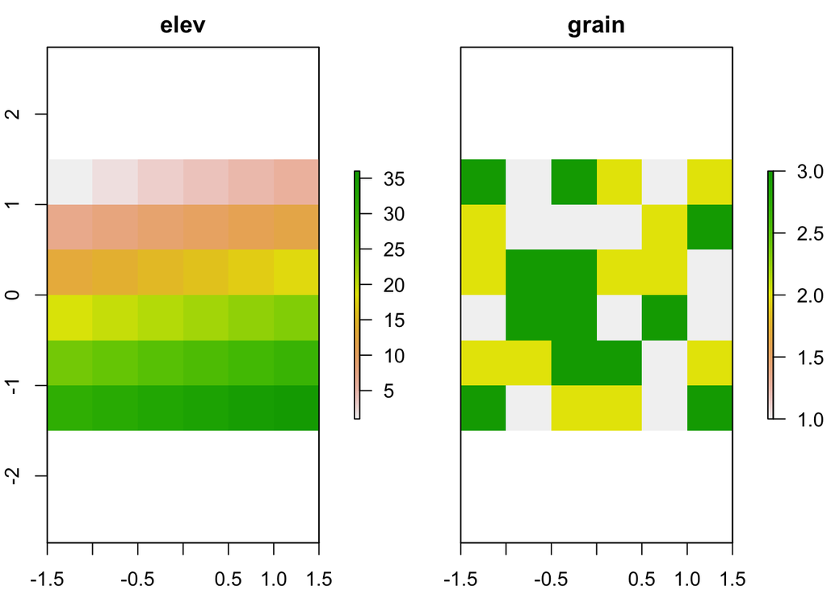

```r
plot(r_stack)
```

Cell values can be modified by overwriting existing values in conjunction with a subsetting operation. The following code chunk, for example, sets the upper left cell of `elev` to 0:

```r
elev[1, 1] = 0
elev[]
```

```
##  [1]  0  2  3  4  5  6  7  8  9 10 11 12 13 14 15 16 17 18 19 20 21 22 23
## [24] 24 25 26 27 28 29 30 31 32 33 34 35 36
```

Leaving the square brackets empty is a shortcut version of `values()` for retrieving all values of a raster. Multiple cells can also be modified in this way:

```r
elev[1, 1:2] = 0
```

### Summarizing raster objects

**raster** contains functions for extracting descriptive statistics for entire rasters. Printing a raster object to the console by typing its name, returns minimum and maximum values of a raster. `summary()` provides common descriptive statistics (minimum, maximum, interquartile range and number of `NA`s). Further summary operations such as the standard deviation (see below) or custom summary statistics can be calculated with `cellStats()`.

```r
cellStats(elev, sd)
```

```
## [1] 10.67808
```

If you provide the `summary()` and `cellStats()` functions with a raster stack or brick object, they will summarize each layer separately, as can be illustrated by running: `summary(brick(elev, grain))`.

Raster value statistics can be visualized in a variety of ways. Specific functions such as `boxplot()`, `density()`, `hist()` and `pairs()` work also with raster objects, as demonstrated in the histogram created with the command below (not shown):

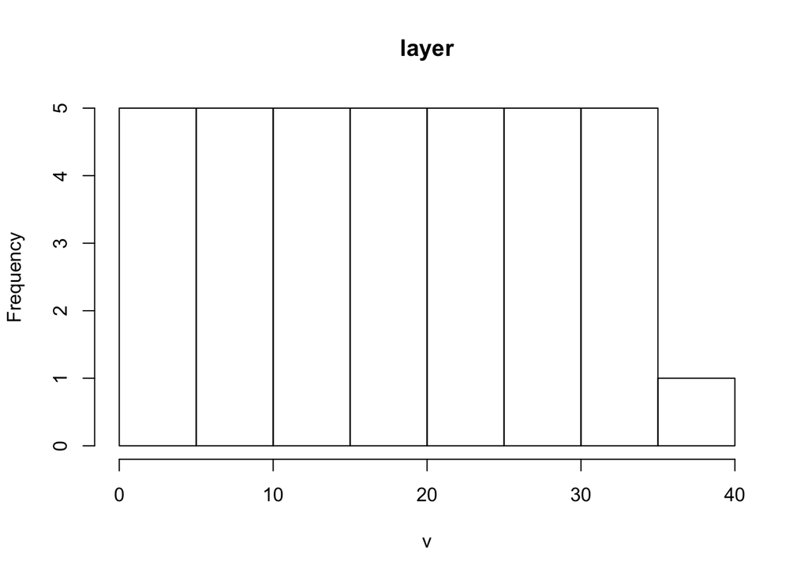

```r
hist(elev)
```

In case a visualization function does not work with raster objects, one can extract the raster data to be plotted with the help of `values()` or `getValues()`.

Descriptive raster statistics belong to the so-called global raster operations. These and other typical raster processing operations are part of the map algebra scheme which are covered in the next chapter (section @ref(map-algebra)).

Some function names clash between packages (e.g. `select`, as discussed in a previous note). In addition to not loading packages by referring to functions verbosely (e.g. `dplyr::select()`) another way to prevent function names clashes is by unloading the offending package with `detach()`. The following command, for example, unloads the **raster** package (this can also be done in the *package* tab which resides by default in the right-bottom pane in RStudio): `detach(“package:raster”, unload = TRUE, force = TRUE)`. The `force` argument makes sure that the package will be detached even if other packages depend on it. This, however, may lead to a restricted usability of packages depending on the detached package, and is therefore not recommended.

[^1]: **data.table** is a high-performance data processing package. Its application to spatial data is covered in a blog post hosted at r-spatial.org/r/2017/11/13/perp-performance.html.
[^2]: `st_geometry(world_st) = NULL` also works to remove the geometry from `world` but overwrites the original object.